# arcticdata-library-1-4

```python
!pip install feature_engine
```

[output not shown]

```python
!pip install arcticdata=="1.4"
```

[output not shown]

[figure not shown]

#### Hello! I'm Javier and im a Data Science Master's Degree student. I have made a library to automate the processes in which data scientists invest most part of the time. The library is divided into three sections: EDA, feature engineering and feature selection.

### Give me a like if you found it useful and leave me a comment if you have any suggestion!

[figure not shown]

```python
import pandas as pd
import arcticdata.ExploratoryDataAnalysis as eda
import arcticdata.FeatureEngineering as fe
import arcticdata.FeatureSelection as fs

import os
for dirname, _, filenames in os.walk('/kaggle/input'):
    for filename in filenames:
        print(os.path.join(dirname, filename))
```

```
/kaggle/input/titanic/train.csv
/kaggle/input/titanic/test.csv
/kaggle/input/titanic/gender_submission.csv
```

## Before starting with the dataset, the library counts with a project checklist if you are lost in any moment and you don't remember what you need to do (This checklist is based in Aurélien Géron book called "Hands-On Machine Learning with Scikit-Learn, Keras & Tensorflow")

```python
eda.project_checklist()
```

```
Frame the problem
	-Define the objective
	-Supervised/Unsupervised, online/offline
	-Measure of the performance
	-Minimum performance needed to reach the objective
	-Assumptions

Get the data
	-Document where is the data
	-Check how much space it takes
	-Check legal obligations and get authorization
	-Create a workspace
	-Convert the data to a good format
	-Delete or protect sensitive information
	-Check the type of data
	-Put a test set aside

Explore the data
	-Create a copy of the data for exploration
	-Study each attribute
	-Identify the target attribute if supervised learning
	-Visualize the data
	-Study the correlations
	-Identify the transformations you need
	-Document what you have learned

Prepare the data
	-Work on copies of the data
	-Write functions for all transformations
	-Data cleaning (outliers and missing values)
	-Feature selection (Drop attributes with no useful information)
	-Feature engineering (Discretize, Decompose, etc)
	-Feature scaling (standardize, normalize)

Shortlist promising models
	-Automate this steps as much as posible
	-Train many quick-and-dirty models using standar parameters
	-Measure and compare the performance with N-fold CV and compute the mean and sd of the performances
	-Analyze the most significant variables for each algorithm
	-Analyze the type of errors the models make
	-Shortlist the top promising models

Fine-Tune the system
	-Fine-Tune hyperparameters using CV
	-Random Search > Grid Search unless very few hyperparameters to explore
	-If training is very long, use Bayesian optimization approach
	-Use ensemble methods for better performance
	-Measure model performance on the test set to get the generalization error

Present your solution
	-Document what you have done
	-Create a nice presentation
	-Explain why the solution archieves the objective
	-Present interesting points and key findings
Launch
	-Get the solution ready to production
	-Write monitoring code and trigger alerts
```

[figure not shown]

## To show what the library can do, we will work with a classic in Data Science, Titanic's dataset

```python
train = pd.read_csv('/kaggle/input/titanic/train.csv')
test = pd.read_csv('/kaggle/input/titanic/test.csv')

train.head(3)
```

|  | PassengerId | Survived | Pclass | Name | Sex | Age | SibSp | Parch | Ticket | Fare | Cabin | Embarked |
| --- | --- | --- | --- | --- | --- | --- | --- | --- | --- | --- | --- | --- |
| 0 | 1 | 0 | 3 | Braund, Mr. Owen Harris | male | 22.0 | 1 | 0 | A/5 21171 | 7.2500 | NaN | S |
| 1 | 2 | 1 | 1 | Cumings, Mrs. John Bradley (Florence Briggs Th... | female | 38.0 | 1 | 0 | PC 17599 | 71.2833 | C85 | C |
| 2 | 3 | 1 | 3 | Heikkinen, Miss. Laina | female | 26.0 | 0 | 0 | STON/O2. 3101282 | 7.9250 | NaN | S |

[figure not shown]

# Looking for correlations

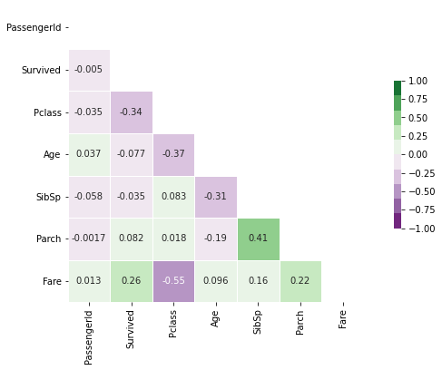

```python
eda.corr_plot(train)
```

# Looking for correlations for one feature

```python
eda.correlation(train,'SibSp')
```

|  | SibSp |
| --- | --- |
| SibSp | 1.000000 |
| Parch | 0.414838 |
| Fare | 0.159651 |
| Pclass | 0.083081 |
| Survived | -0.035322 |
| PassengerId | -0.057527 |
| Age | -0.308247 |

# Looking for missing values

|  | Total | Percent |
| --- | --- | --- |
| Cabin | 687 | 77.104377 |
| Age | 177 | 19.865320 |
| Embarked | 2 | 0.224467 |
| PassengerId | 0 | 0.000000 |
| Survived | 0 | 0.000000 |
| Pclass | 0 | 0.000000 |
| Name | 0 | 0.000000 |
| Sex | 0 | 0.000000 |
| SibSp | 0 | 0.000000 |
| Parch | 0 | 0.000000 |
| Ticket | 0 | 0.000000 |
| Fare | 0 | 0.000000 |

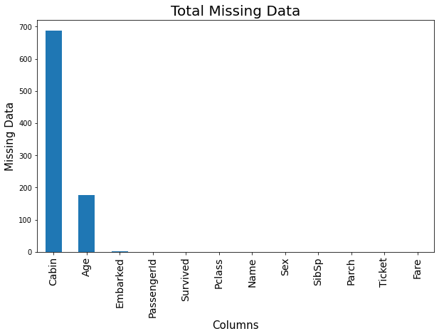

```python
eda.missing_data(train,count=True)
```

|  | Total | Percent |
| --- | --- | --- |
| Cabin | 687 | 77.104377 |
| Age | 177 | 19.865320 |
| Embarked | 2 | 0.224467 |
| PassengerId | 0 | 0.000000 |
| Survived | 0 | 0.000000 |
| Pclass | 0 | 0.000000 |
| Name | 0 | 0.000000 |
| Sex | 0 | 0.000000 |
| SibSp | 0 | 0.000000 |
| Parch | 0 | 0.000000 |
| Ticket | 0 | 0.000000 |
| Fare | 0 | 0.000000 |

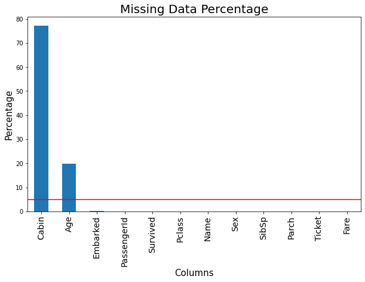

```python
eda.missing_data(train, percentage=True)
```

# Distribution of numerical features

```python
eda.distribution_diag(train,'Age')
```

[output not shown]

# Outliers

### It's normal to have some outliers, but we need to easy detect if there is something wrong with our dataset. We can use IQR method (1.5*IQR) or IQR3 (3*IQR) to get the outliers

```python
eda.outliers(train,'Age',method='IQR',table=True, limits=True)
```

```
MIN: -6.6875
MAX: 64.8125
```

|  | PassengerId | Survived | Pclass | Name | Sex | Age | SibSp | Parch | Ticket | Fare | Cabin | Embarked |
| --- | --- | --- | --- | --- | --- | --- | --- | --- | --- | --- | --- | --- |
| 33 | 34 | 0 | 2 | Wheadon, Mr. Edward H | male | 66.0 | 0 | 0 | C.A. 24579 | 10.5000 | NaN | S |
| 54 | 55 | 0 | 1 | Ostby, Mr. Engelhart Cornelius | male | 65.0 | 0 | 1 | 113509 | 61.9792 | B30 | C |
| 96 | 97 | 0 | 1 | Goldschmidt, Mr. George B | male | 71.0 | 0 | 0 | PC 17754 | 34.6542 | A5 | C |
| 116 | 117 | 0 | 3 | Connors, Mr. Patrick | male | 70.5 | 0 | 0 | 370369 | 7.7500 | NaN | Q |
| 280 | 281 | 0 | 3 | Duane, Mr. Frank | male | 65.0 | 0 | 0 | 336439 | 7.7500 | NaN | Q |
| 456 | 457 | 0 | 1 | Millet, Mr. Francis Davis | male | 65.0 | 0 | 0 | 13509 | 26.5500 | E38 | S |
| 493 | 494 | 0 | 1 | Artagaveytia, Mr. Ramon | male | 71.0 | 0 | 0 | PC 17609 | 49.5042 | NaN | C |
| 630 | 631 | 1 | 1 | Barkworth, Mr. Algernon Henry Wilson | male | 80.0 | 0 | 0 | 27042 | 30.0000 | A23 | S |
| 672 | 673 | 0 | 2 | Mitchell, Mr. Henry Michael | male | 70.0 | 0 | 0 | C.A. 24580 | 10.5000 | NaN | S |
| 745 | 746 | 0 | 1 | Crosby, Capt. Edward Gifford | male | 70.0 | 1 | 1 | WE/P 5735 | 71.0000 | B22 | S |
| 851 | 852 | 0 | 3 | Svensson, Mr. Johan | male | 74.0 | 0 | 0 | 347060 | 7.7750 | NaN | S |

```python
eda.outliers(train,'Age',method='IQR3',table=True, limits=True)
```

```
MIN: -33.5
MAX: 91.625
```

|  | PassengerId | Survived | Pclass | Name | Sex | Age | SibSp | Parch | Ticket | Fare | Cabin | Embarked |
| --- | --- | --- | --- | --- | --- | --- | --- | --- | --- | --- | --- | --- |

# Value count for categorical features

|  | Total | Percent |
| --- | --- | --- |
| S | 644 | 72.278339 |
| C | 168 | 18.855219 |
| Q | 77 | 8.641975 |

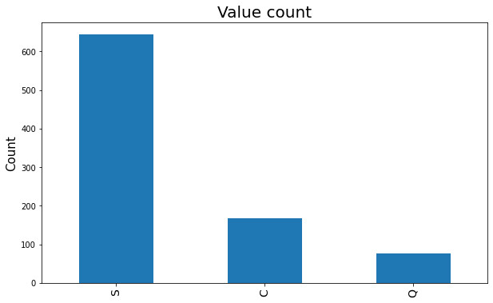

```python
eda.value_counts(train.Embarked, count=True)
```

|  | Total | Percent |
| --- | --- | --- |
| S | 644 | 72.278339 |
| C | 168 | 18.855219 |
| Q | 77 | 8.641975 |

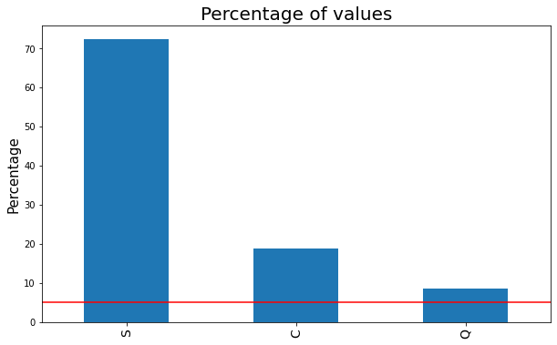

```python
eda.value_counts(train.Embarked, percentage=True)
```

# Getting all the functions together

```python
eda.feature_analysis(train, "Age", test=test)
```

```
The feature Age is NUMERIC

-Missing values in training set: 177
-Missing values in test set    : 86
-Outliers 1.5*IQR: 11
-Outliers   3*IQR: 0
```

```
The feature Embarked is CATEGORICAL

-Cardinality: 4
-Missing values in training set: 2
-Missing values in test set    : 0
```

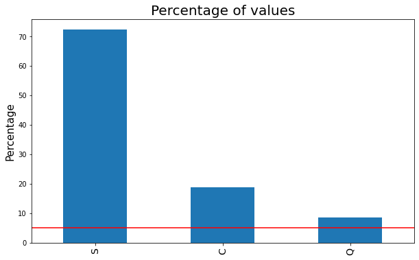

```python
eda.feature_analysis(train, "Embarked", test=test)
```

```
The feature Fare is NUMERIC

-Missing values in training set: 0
-Missing values in test set    : 1
-Outliers 1.5*IQR: 116
-Outliers   3*IQR: 53
```

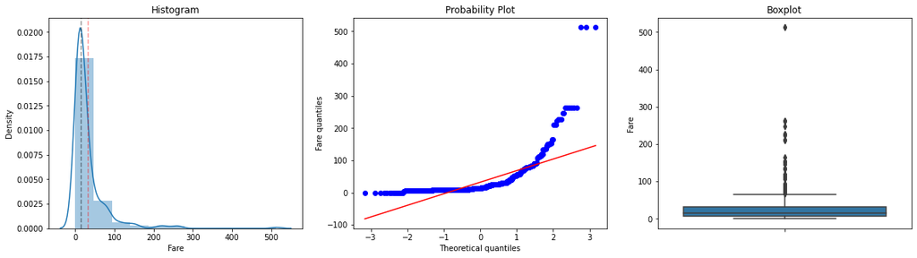

```python
eda.feature_analysis(train, "Fare", test=test)
```

```python
eda.feature_analysis(train, "Cabin", test=test)
```

```
The feature Cabin is CATEGORICAL

-Cardinality: 148
-Missing values in training set: 687
-Missing values in test set    : 327
-THE CARDINALITY IS TOO BIG
```

[figure not shown]

# Imputing missing values

```python
eda.distribution_diag(train,'Age')
```

[output not shown]

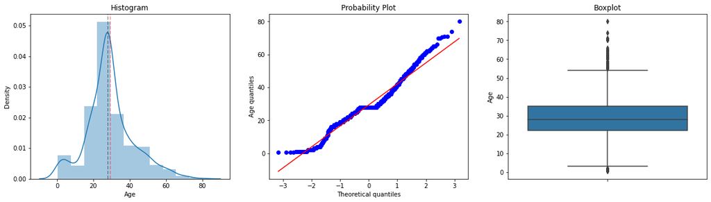

```python
x=fe.impute_missing(train,train,method='median')
eda.distribution_diag(x,'Age')
```

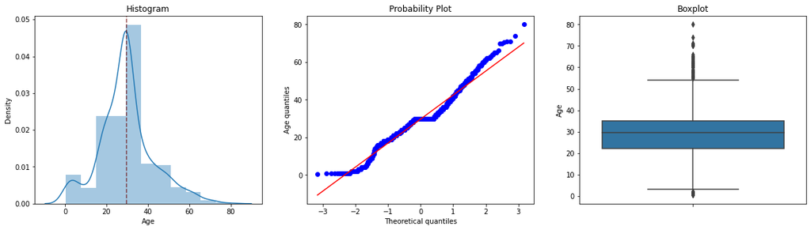

```python
x=fe.impute_missing(train,train,method='mean')
eda.distribution_diag(x,'Age')
```

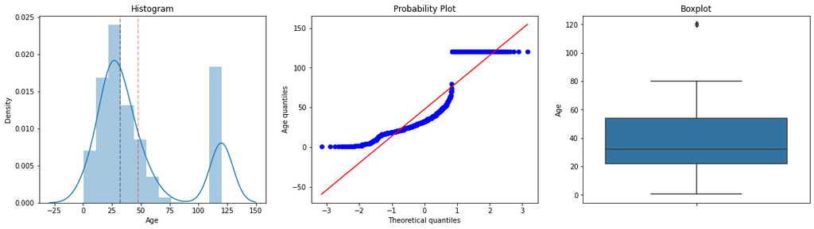

```python
x=fe.impute_missing(train,train,method='arbitrary',arbitrary_number=120)
eda.distribution_diag(x,'Age')
```

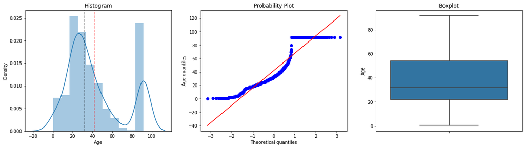

```python
x=fe.impute_missing(train,train,method='tail',tail='right')
eda.distribution_diag(x,'Age')
```

```python
x=fe.impute_missing(train,train,method='indicator')
x['Embarked_na'].sample(5)
```

```
557    0
280    0
54     0
550    0
70     0
Name: Embarked_na, dtype: int64
```

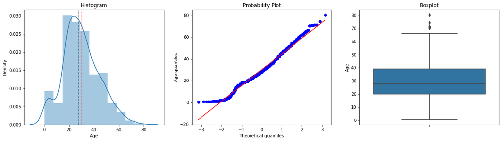

```python
x=fe.impute_missing(train,train,method='random')
eda.distribution_diag(x,'Age')
```

|  | Total | Percent |
| --- | --- | --- |
| S | 646 | 72.502806 |
| C | 168 | 18.855219 |
| Q | 77 | 8.641975 |

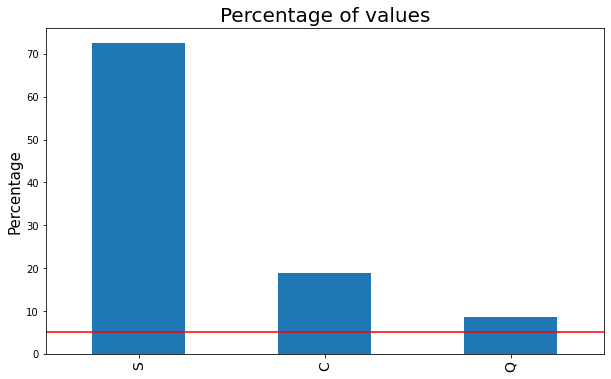

```python
x=fe.impute_missing(train.Embarked.to_frame(),train.Embarked.to_frame(),method='mode')
eda.value_counts(x.Embarked,percentage=True)
```

|  | Total | Percent |
| --- | --- | --- |
| S | 644 | 72.278339 |
| C | 168 | 18.855219 |
| Q | 77 | 8.641975 |
| Missing | 2 | 0.224467 |

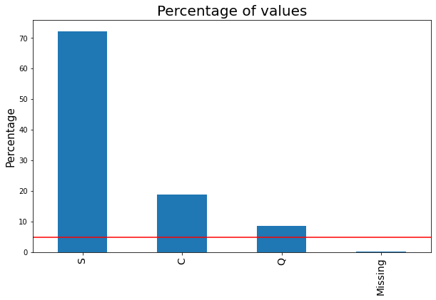

```python
x=fe.impute_missing(train.Embarked.to_frame(),train.Embarked.to_frame(),method='category')
eda.value_counts(x.Embarked,percentage=True)
```

```python
train = fe.impute_missing(train,train,method='random')
test = fe.impute_missing(train.drop("Survived",axis=1),test,method='random')
```

# Grouping rare labels

|  | Total | Percent |
| --- | --- | --- |
| C | 261 | 29.292929 |
| B | 184 | 20.650954 |
| D | 155 | 17.396184 |
| E | 150 | 16.835017 |
| A | 63 | 7.070707 |
| F | 59 | 6.621773 |
| G | 16 | 1.795735 |
| T | 3 | 0.336700 |

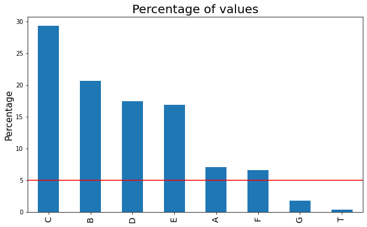

```python
train['Cabin'] = train['Cabin'].str[0]
test['Cabin'] = test['Cabin'].str[0]
eda.value_counts(train.Cabin,percentage=True)
```

|  | Total | Percent |
| --- | --- | --- |
| C | 261 | 29.292929 |
| B | 184 | 20.650954 |
| D | 155 | 17.396184 |
| E | 150 | 16.835017 |
| A | 63 | 7.070707 |
| F | 59 | 6.621773 |
| Rare | 19 | 2.132435 |

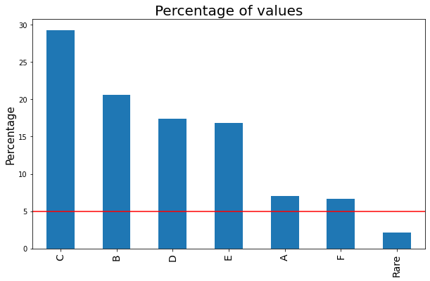

```python
x=fe.group_rare_labels(train.Cabin,train.Cabin,tol=0.05)
eda.value_counts(x.Cabin,percentage=True)
```

```python
train.drop("Name",axis=1,inplace=True)
train.drop("Ticket",axis=1,inplace=True)
test.drop("Name",axis=1,inplace=True)
test.drop("Ticket",axis=1,inplace=True)
```

# Transformation of numerical features

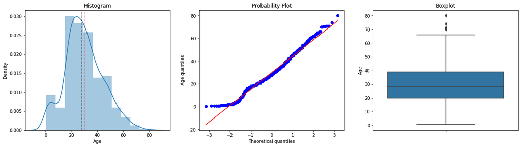

```python
eda.distribution_diag(train,'Age')
```

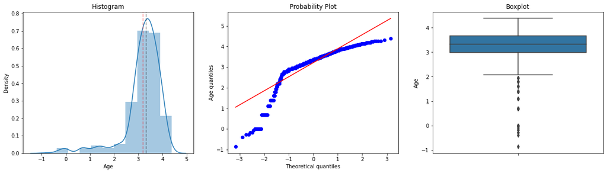

```python
x = fe.transform(train,'log',variables=['Age'])
eda.distribution_diag(x,'Age')
```

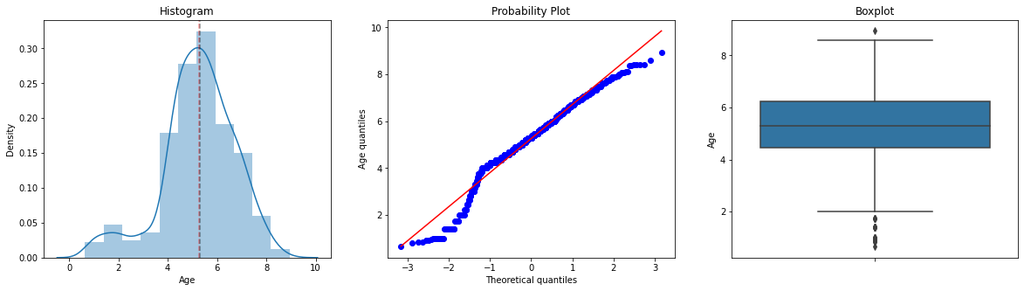

```python
x = fe.transform(train,'exp',variables=['Age'])
eda.distribution_diag(x,'Age')
```

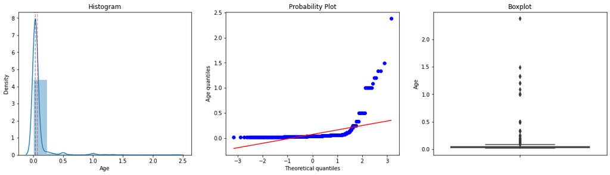

```python
x = fe.transform(train,'inv',variables=['Age'])
eda.distribution_diag(x,'Age')
```

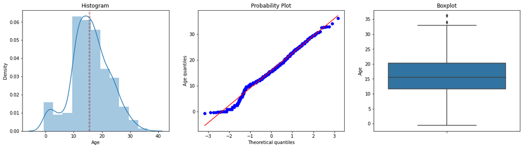

```python
x = fe.transform(train,'boxcox',variables=['Age'])
eda.distribution_diag(x,'Age')
```

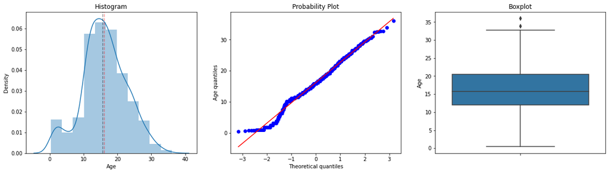

```python
x = fe.transform(train,'yeo',variables=['Age'])
eda.distribution_diag(x,'Age')
```

# Discretization of numerical features

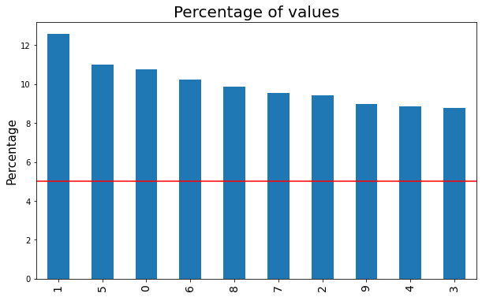

```python
x = fe.discretization(train, train, method='equalfreq',variables=['Age'])
eda.value_counts(x.Age,percentage=True,table=False)
```

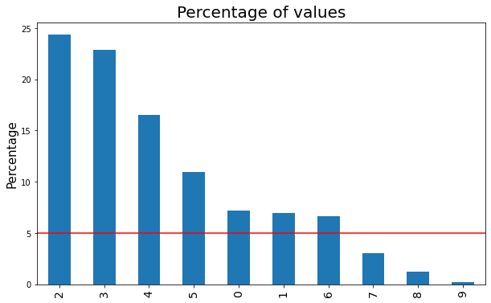

```python
x = fe.discretization(train, train, method='equalrange',variables=['Age'])
eda.value_counts(x.Age,percentage=True,table=False)
```

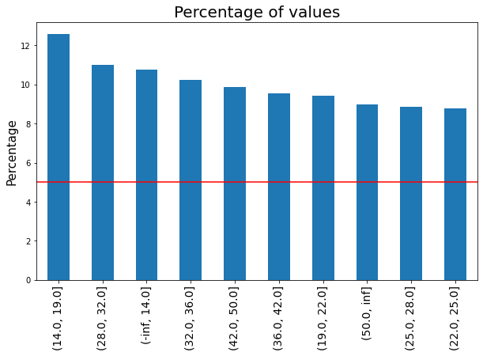

```python
x = fe.discretization(train, train, method='equalfreq',variables=['Age'],return_boundaries=True)
eda.value_counts(x.Age,percentage=True,table=False)
```

# Encoding of categorical features

```python
x = fe.encoding(train, train, method='order', variables=['Cabin'])
x.head()
```

|  | PassengerId | Survived | Pclass | Sex | Age | SibSp | Parch | Fare | Cabin | Embarked |
| --- | --- | --- | --- | --- | --- | --- | --- | --- | --- | --- |
| 0 | 1 | 0 | 3 | male | 22.0 | 1 | 0 | 7.2500 | 0 | S |
| 1 | 2 | 1 | 1 | female | 38.0 | 1 | 0 | 71.2833 | 1 | C |
| 2 | 3 | 1 | 3 | female | 26.0 | 0 | 0 | 7.9250 | 2 | S |
| 3 | 4 | 1 | 1 | female | 35.0 | 1 | 0 | 53.1000 | 1 | S |
| 4 | 5 | 0 | 3 | male | 35.0 | 0 | 0 | 8.0500 | 3 | S |

```python
x = fe.encoding(train, train, method='onehot', variables=['Cabin'])
x.head()
```

|  | PassengerId | Survived | Pclass | Sex | Age | SibSp | Parch | Fare | Embarked | Cabin_B | Cabin_C | Cabin_D | Cabin_F | Cabin_E | Cabin_G | Cabin_A |
| --- | --- | --- | --- | --- | --- | --- | --- | --- | --- | --- | --- | --- | --- | --- | --- | --- |
| 0 | 1 | 0 | 3 | male | 22.0 | 1 | 0 | 7.2500 | S | 1 | 0 | 0 | 0 | 0 | 0 | 0 |
| 1 | 2 | 1 | 1 | female | 38.0 | 1 | 0 | 71.2833 | C | 0 | 1 | 0 | 0 | 0 | 0 | 0 |
| 2 | 3 | 1 | 3 | female | 26.0 | 0 | 0 | 7.9250 | S | 0 | 0 | 1 | 0 | 0 | 0 | 0 |
| 3 | 4 | 1 | 1 | female | 35.0 | 1 | 0 | 53.1000 | S | 0 | 1 | 0 | 0 | 0 | 0 | 0 |
| 4 | 5 | 0 | 3 | male | 35.0 | 0 | 0 | 8.0500 | S | 0 | 0 | 0 | 1 | 0 | 0 | 0 |

```python
test = fe.encoding(train.drop("Survived",axis=1), test)
train = fe.encoding(train, train)
```

# Numerical features scaling

```python
x = fe.scale(train, method='standar')
x.head()
```

|  | PassengerId | Survived | Pclass | Age | SibSp | Parch | Fare | Sex_male | Cabin_B | Cabin_C | Cabin_D | Cabin_F | Cabin_E | Cabin_G | Cabin_A | Embarked_S | Embarked_C |
| --- | --- | --- | --- | --- | --- | --- | --- | --- | --- | --- | --- | --- | --- | --- | --- | --- | --- |
| 0 | -1.730108 | -0.789272 | 0.827377 | -0.542539 | 0.432793 | -0.473674 | -0.502445 | 0.737695 | 1.960202 | -0.643650 | -0.458909 | -0.266296 | -0.449921 | -0.135225 | -0.275839 | 0.619306 | -0.483810 |
| 1 | -1.726220 | 1.266990 | -1.566107 | 0.562433 | 0.432793 | -0.473674 | 0.786845 | -1.355574 | -0.510152 | 1.553639 | -0.458909 | -0.266296 | -0.449921 | -0.135225 | -0.275839 | -1.614710 | 2.066928 |
| 2 | -1.722332 | 1.266990 | 0.827377 | -0.266296 | -0.474545 | -0.473674 | -0.488854 | -1.355574 | -0.510152 | -0.643650 | 2.179079 | -0.266296 | -0.449921 | -0.135225 | -0.275839 | 0.619306 | -0.483810 |
| 3 | -1.718444 | 1.266990 | -1.566107 | 0.355250 | 0.432793 | -0.473674 | 0.420730 | -1.355574 | -0.510152 | 1.553639 | -0.458909 | -0.266296 | -0.449921 | -0.135225 | -0.275839 | 0.619306 | -0.483810 |
| 4 | -1.714556 | -0.789272 | 0.827377 | 0.355250 | -0.474545 | -0.473674 | -0.486337 | 0.737695 | -0.510152 | -0.643650 | -0.458909 | 3.755222 | -0.449921 | -0.135225 | -0.275839 | 0.619306 | -0.483810 |

```python
x = fe.scale(train, method='normal')
x.head()
```

|  | PassengerId | Survived | Pclass | Age | SibSp | Parch | Fare | Sex_male | Cabin_B | Cabin_C | Cabin_D | Cabin_F | Cabin_E | Cabin_G | Cabin_A | Embarked_S | Embarked_C |
| --- | --- | --- | --- | --- | --- | --- | --- | --- | --- | --- | --- | --- | --- | --- | --- | --- | --- |
| 0 | 0.026846 | 0.000000 | 0.080537 | 0.590604 | 0.026846 | 0.0 | 0.194631 | 0.026846 | 0.026846 | 0.000000 | 0.000000 | 0.000000 | 0.0 | 0.0 | 0.0 | 0.026846 | 0.0000 |
| 1 | 0.017199 | 0.008600 | 0.008600 | 0.326788 | 0.008600 | 0.0 | 0.613014 | 0.000000 | 0.000000 | 0.008600 | 0.000000 | 0.000000 | 0.0 | 0.0 | 0.0 | 0.000000 | 0.0086 |
| 2 | 0.069889 | 0.023296 | 0.069889 | 0.605708 | 0.000000 | 0.0 | 0.184624 | 0.000000 | 0.000000 | 0.000000 | 0.023296 | 0.000000 | 0.0 | 0.0 | 0.0 | 0.023296 | 0.0000 |
| 3 | 0.041195 | 0.010299 | 0.010299 | 0.360453 | 0.010299 | 0.0 | 0.546859 | 0.000000 | 0.000000 | 0.010299 | 0.000000 | 0.000000 | 0.0 | 0.0 | 0.0 | 0.010299 | 0.0000 |
| 4 | 0.092507 | 0.000000 | 0.055504 | 0.647549 | 0.000000 | 0.0 | 0.148936 | 0.018501 | 0.000000 | 0.000000 | 0.000000 | 0.018501 | 0.0 | 0.0 | 0.0 | 0.018501 | 0.0000 |

```python
x = fe.scale(train, method='minmax')
x.head()
```

|  | PassengerId | Survived | Pclass | Age | SibSp | Parch | Fare | Sex_male | Cabin_B | Cabin_C | Cabin_D | Cabin_F | Cabin_E | Cabin_G | Cabin_A | Embarked_S | Embarked_C |
| --- | --- | --- | --- | --- | --- | --- | --- | --- | --- | --- | --- | --- | --- | --- | --- | --- | --- |
| 0 | 0.000000 | 0.0 | 1.0 | 0.271174 | 0.125 | 0.0 | 0.014151 | 1.0 | 1.0 | 0.0 | 0.0 | 0.0 | 0.0 | 0.0 | 0.0 | 1.0 | 0.0 |
| 1 | 0.001124 | 1.0 | 0.0 | 0.472229 | 0.125 | 0.0 | 0.139136 | 0.0 | 0.0 | 1.0 | 0.0 | 0.0 | 0.0 | 0.0 | 0.0 | 0.0 | 1.0 |
| 2 | 0.002247 | 1.0 | 1.0 | 0.321438 | 0.000 | 0.0 | 0.015469 | 0.0 | 0.0 | 0.0 | 1.0 | 0.0 | 0.0 | 0.0 | 0.0 | 1.0 | 0.0 |
| 3 | 0.003371 | 1.0 | 0.0 | 0.434531 | 0.125 | 0.0 | 0.103644 | 0.0 | 0.0 | 1.0 | 0.0 | 0.0 | 0.0 | 0.0 | 0.0 | 1.0 | 0.0 |
| 4 | 0.004494 | 0.0 | 1.0 | 0.434531 | 0.000 | 0.0 | 0.015713 | 1.0 | 0.0 | 0.0 | 0.0 | 1.0 | 0.0 | 0.0 | 0.0 | 1.0 | 0.0 |

```python
train = fe.scale(train)
test = fe.scale(test)
```

[figure not shown]

# Drop constant features

```python
x = fs.dropconstant(train, tol=0.998)
x.head()
```

|  | PassengerId | Survived | Pclass | Age | SibSp | Parch | Fare | Sex_male | Cabin_B | Cabin_C | Cabin_D | Cabin_F | Cabin_E | Cabin_G | Cabin_A | Embarked_S | Embarked_C |
| --- | --- | --- | --- | --- | --- | --- | --- | --- | --- | --- | --- | --- | --- | --- | --- | --- | --- |
| 0 | 0.000000 | 0.0 | 1.0 | 0.271174 | 0.125 | 0.0 | 0.014151 | 1.0 | 1.0 | 0.0 | 0.0 | 0.0 | 0.0 | 0.0 | 0.0 | 1.0 | 0.0 |
| 1 | 0.001124 | 1.0 | 0.0 | 0.472229 | 0.125 | 0.0 | 0.139136 | 0.0 | 0.0 | 1.0 | 0.0 | 0.0 | 0.0 | 0.0 | 0.0 | 0.0 | 1.0 |
| 2 | 0.002247 | 1.0 | 1.0 | 0.321438 | 0.000 | 0.0 | 0.015469 | 0.0 | 0.0 | 0.0 | 1.0 | 0.0 | 0.0 | 0.0 | 0.0 | 1.0 | 0.0 |
| 3 | 0.003371 | 1.0 | 0.0 | 0.434531 | 0.125 | 0.0 | 0.103644 | 0.0 | 0.0 | 1.0 | 0.0 | 0.0 | 0.0 | 0.0 | 0.0 | 1.0 | 0.0 |
| 4 | 0.004494 | 0.0 | 1.0 | 0.434531 | 0.000 | 0.0 | 0.015713 | 1.0 | 0.0 | 0.0 | 0.0 | 1.0 | 0.0 | 0.0 | 0.0 | 1.0 | 0.0 |

# Drop duplicated features

```python
x = fs.dropduplicated(train)
x.head()
```

|  | PassengerId | Survived | Pclass | Age | SibSp | Parch | Fare | Sex_male | Cabin_B | Cabin_C | Cabin_D | Cabin_F | Cabin_E | Cabin_G | Cabin_A | Embarked_S | Embarked_C |
| --- | --- | --- | --- | --- | --- | --- | --- | --- | --- | --- | --- | --- | --- | --- | --- | --- | --- |
| 0 | 0.000000 | 0.0 | 1.0 | 0.271174 | 0.125 | 0.0 | 0.014151 | 1.0 | 1.0 | 0.0 | 0.0 | 0.0 | 0.0 | 0.0 | 0.0 | 1.0 | 0.0 |
| 1 | 0.001124 | 1.0 | 0.0 | 0.472229 | 0.125 | 0.0 | 0.139136 | 0.0 | 0.0 | 1.0 | 0.0 | 0.0 | 0.0 | 0.0 | 0.0 | 0.0 | 1.0 |
| 2 | 0.002247 | 1.0 | 1.0 | 0.321438 | 0.000 | 0.0 | 0.015469 | 0.0 | 0.0 | 0.0 | 1.0 | 0.0 | 0.0 | 0.0 | 0.0 | 1.0 | 0.0 |
| 3 | 0.003371 | 1.0 | 0.0 | 0.434531 | 0.125 | 0.0 | 0.103644 | 0.0 | 0.0 | 1.0 | 0.0 | 0.0 | 0.0 | 0.0 | 0.0 | 1.0 | 0.0 |
| 4 | 0.004494 | 0.0 | 1.0 | 0.434531 | 0.000 | 0.0 | 0.015713 | 1.0 | 0.0 | 0.0 | 0.0 | 1.0 | 0.0 | 0.0 | 0.0 | 1.0 | 0.0 |

# Drop correlated features

```python
x = fs.dropcorrelated(train, threshold=0.8)
x.head()
```

|  | PassengerId | Survived | Pclass | Age | SibSp | Parch | Fare | Sex_male | Cabin_B | Cabin_C | Cabin_D | Cabin_F | Cabin_E | Cabin_G | Cabin_A | Embarked_S | Embarked_C |
| --- | --- | --- | --- | --- | --- | --- | --- | --- | --- | --- | --- | --- | --- | --- | --- | --- | --- |
| 0 | 0.000000 | 0.0 | 1.0 | 0.271174 | 0.125 | 0.0 | 0.014151 | 1.0 | 1.0 | 0.0 | 0.0 | 0.0 | 0.0 | 0.0 | 0.0 | 1.0 | 0.0 |
| 1 | 0.001124 | 1.0 | 0.0 | 0.472229 | 0.125 | 0.0 | 0.139136 | 0.0 | 0.0 | 1.0 | 0.0 | 0.0 | 0.0 | 0.0 | 0.0 | 0.0 | 1.0 |
| 2 | 0.002247 | 1.0 | 1.0 | 0.321438 | 0.000 | 0.0 | 0.015469 | 0.0 | 0.0 | 0.0 | 1.0 | 0.0 | 0.0 | 0.0 | 0.0 | 1.0 | 0.0 |
| 3 | 0.003371 | 1.0 | 0.0 | 0.434531 | 0.125 | 0.0 | 0.103644 | 0.0 | 0.0 | 1.0 | 0.0 | 0.0 | 0.0 | 0.0 | 0.0 | 1.0 | 0.0 |
| 4 | 0.004494 | 0.0 | 1.0 | 0.434531 | 0.000 | 0.0 | 0.015713 | 1.0 | 0.0 | 0.0 | 0.0 | 1.0 | 0.0 | 0.0 | 0.0 | 1.0 | 0.0 |

# Step forward feature selection

```python
from sklearn.ensemble import RandomForestClassifier

model = RandomForestClassifier()
```

```python
fs.step_forward(train.drop("Survived",axis=1), train['Survived'],model,kfeatures=16,info=True)
```

[output not shown]

[output cut: 10 more lines]

[output not shown]

```
['PassengerId',
 'Pclass',
 'Age',
 'SibSp',
 'Parch',
 'Fare',
 'Sex_male',
 'Cabin_B',
 'Cabin_C',
 'Cabin_D',
 'Cabin_F',
 'Cabin_E',
 'Cabin_G',
 'Cabin_A',
 'Embarked_S',
 'Embarked_C']
```

# Thanks for watching! Like the notebook if you like it!